# Food Products from Plants

## Humans Need Diverse Nutrients from Food Supply

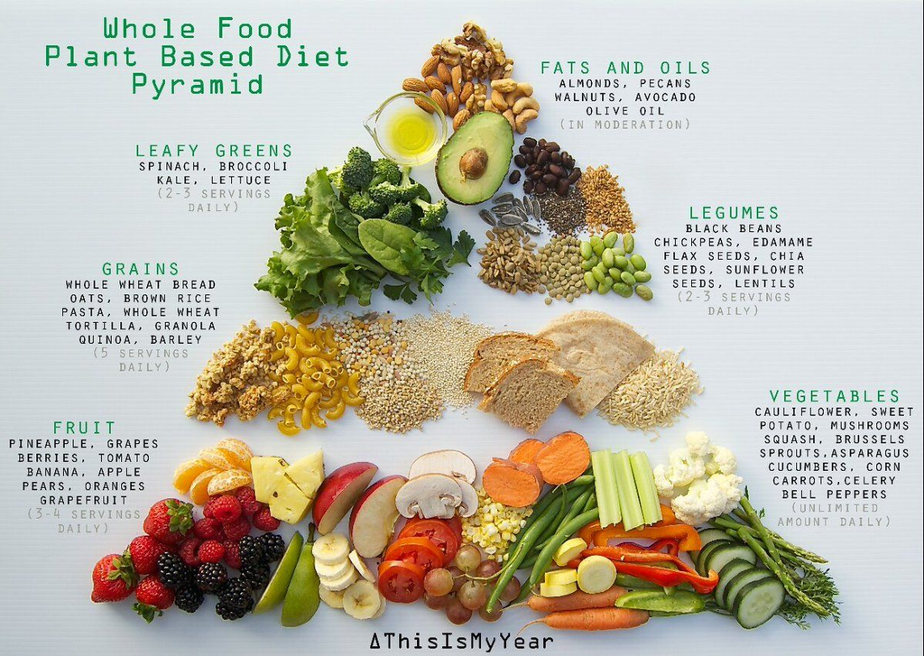

- **Macro-nutrients: Carbohydrates, proteins & fats**
  - carbohydrates & fats provide energy
  - proteins used as building blocks
- **Micro-nutrients: vitamins and minerals**
- **When water removed from plants, mass is just macro-nutrients**
  - foraging → agriculture → population ↑
- **Health advocates & advertisers promote diets based on these requirements**
  - plants can satisfy most of these resource needs

## Complex Carbohydrates from Plants

- **Commonly grouped into sugars and starches**
  - mono-, di- & polysaccharides (# of sugar units)
- **Glucose & fructose (mono-) broken down in cellular respiration**
  - corn syrup = high fructose
  - fructose common in fruit
- **Sucrose (di-) commonly found in table sugar**
  - sugarcane and sugar beet
- **Starches (poly-) are main storage form in plants**
  - seeds, fruits, tubers
  - major staple crops and underground crops

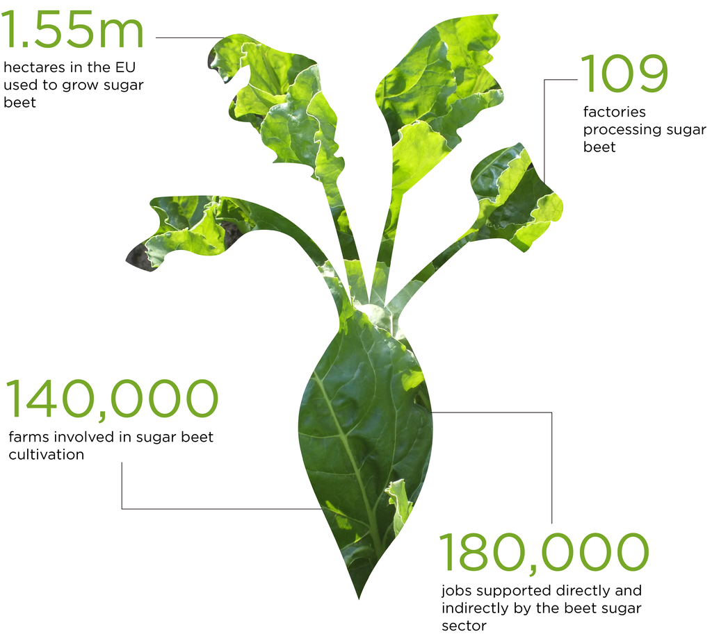

## Fiber in the Human Diet

- **Fiber, a polysaccharides, is largely not digestible**
  - derived from plant sources
- **Cellulose, lignin, pectin are components of cell walls**
  - humans lack enzymes to break them down
- **Bacteria in intestines ferment soluble fibers!**
  - stabilizes blood glucose
  - reduce cholesterol
  - reduces cancer risks

[figure not shown]

## Plant-Based Proteins

- **20 types of amino acids assembled into proteins**
  - regulate a variety of body functions
  - proteins broken down by enzymes and transported through blood
- **Dietary proteins need to provide 9 of 20 amino acids**
  - essential amino acids (9) not created or stored
- **Plant-based proteins are ‘incomplete’**
  - do not contain all 9
  - varied plant diet needed

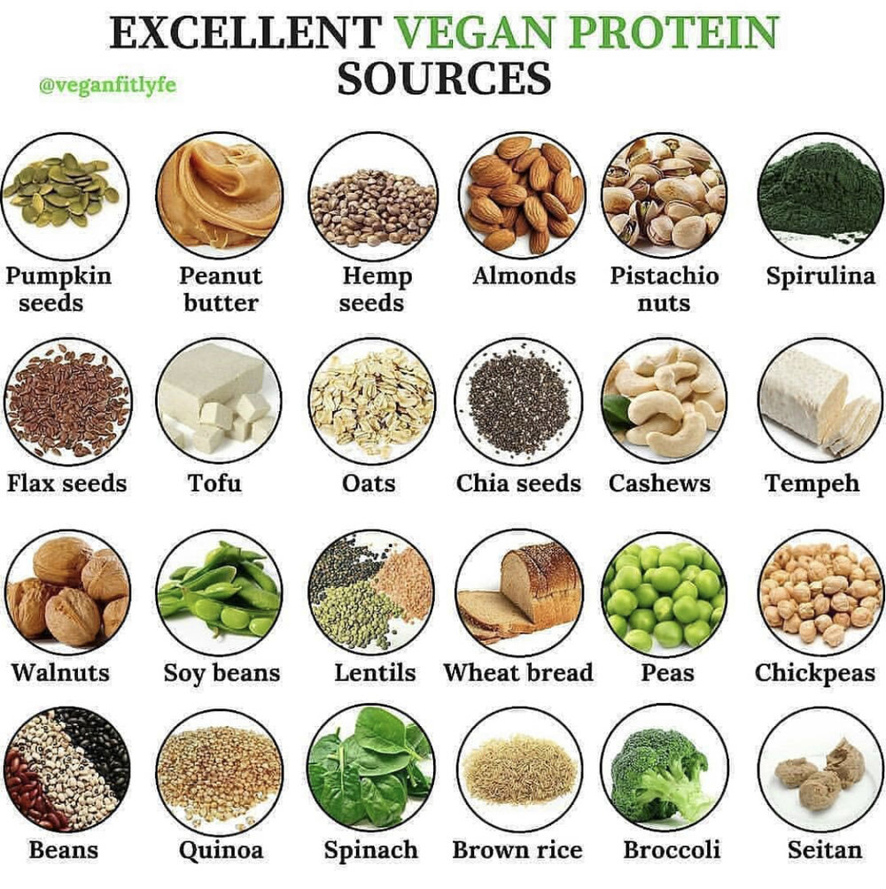

## Complementary Proteins and Food Culture

- **Humans need 9 essential amino acids from diet. Plants often have “incomplete” amino acid profiles alone**
- **Traditional cuisines solve this by pairing crops:**
  - Corn + beans (Mesoamerica)
  - Rice + soy/leafy greens (East Asia)
  - Lentils + wheat flatbread (South Asia / Middle East)
- **This is agricultural engineering through culture**
- **People didn’t “accidentally” invent tortillas + beans, dal + roti, rice + tofu/greens. These pairings systematically close amino acid gaps**
  - traditional agricultural societies have been doing complete-amino-acid engineering for thousands of years based of simple knowledge of what makes people healthy

[figure not shown]

## Gluten and Celiac Disease

**Gluten is a group of storage proteins (mostly from wheat, also barley and rye)**

[figure not shown]

[figure not shown]

## Fats and Cholesterol from Plants

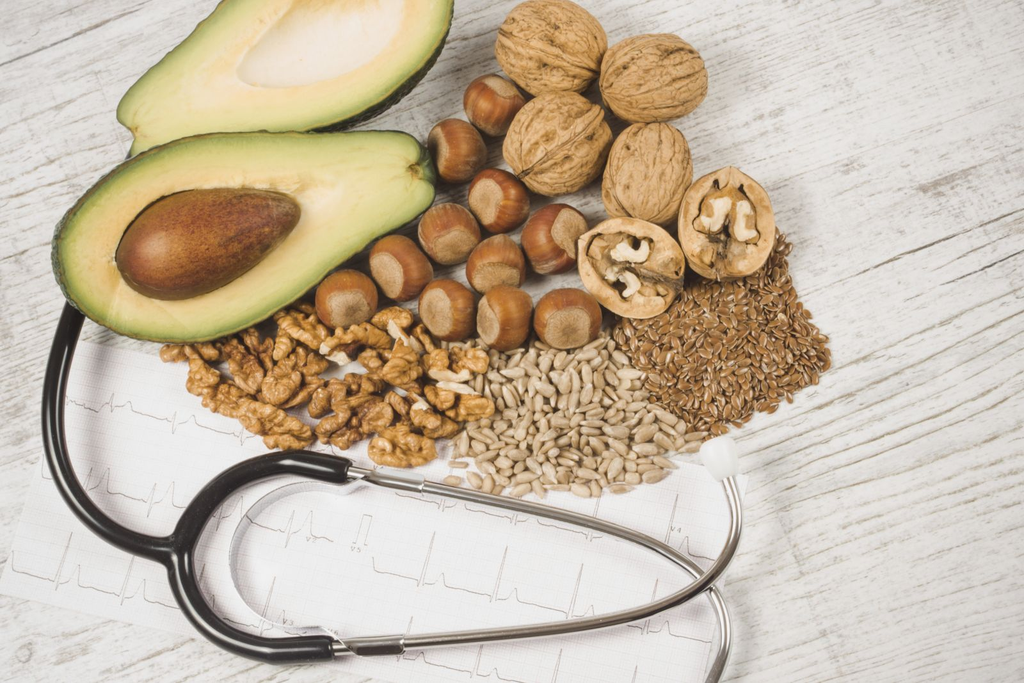

- **Some fats (lipids) are necessary in human diets**
  - vital functions and heart health
- **Food lipids are mostly fats and oils**
- **Human body cannot synthesis all fatty acids**
  - linoleic, linolenic & arachidonic acids
  - all available in vegetable oils
  - 1 tsp of corn oil supply each
- **Vegetable oils are mostly unsaturated fats**
  - olive, peanut, corn, soybean, etc,
  - unsaturated fats generally considered healthier

## Vegetable Oils and Global Cooking

- **Humans need certain fatty acids we cannot make ourselves**
  - Linoleic, linolenic, arachidonic acids
  - oils are more than just a cooking medium
- **Plant oils deliver these:**
  - soybean oil, corn oil, sunflower oil
  - olive oil, palm oil, coconut oil
- **Unsaturated fats: generally linked to better cardiovascular health than animal saturated fats**
- **BUT: source matters → palm oil expansion = tropical deforestation**
  - many fast food resturants use a mix of oils (with palm oil) for frying

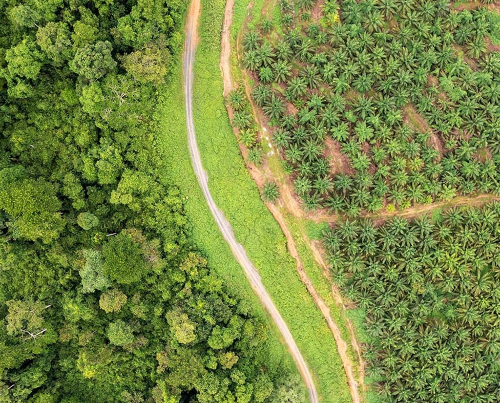

## Micro-Nutrients from Plants

- **Vitamins (organic molecules) play a role as co-enzymes**
  - required for enzyme function
  - only need milligrams or micrograms, but without them, metabolism falls apart
- **Vitamin A (vision pigments) from yellow, orange and dark green vegetables and fruits**
  - beta-carotene from plants converted to vitamin A
- **Vitamin C (collagen synthesis)**
  - not produced or stored in body
  - fruits and vegetables

[figure not shown]

## Micro-Nutrients from Plants

- **Minerals (inorganic) components of complex molecules**
  - at least 18 minerals needed (iron, calcium, etc. )
- **Iron deficiency is common in women and children**
  - only 10% of dietary iron absorbed
  - leafy greens, grains, legumes and dried fruits
- **Iron from animal = heme; from plants = non-heme**
  - heme gives blood its red color
  - some plants, like legumes, contain heme.

[figure not shown]

## Plant Secondary Metabolites = Flavor, Medicine, Addiction

- **Plants play biochemical chess. They make bitter, spicy, numbing, stimulant molecules to defend themselves.**
- **Many familiar flavors are plant defense compounds:**
  - Caffeine (coffee, tea)
  - Capsaicin (chile peppers)
  - Menthol (mint)
  - Vanillin (vanilla pods)
- **Humans turned these “don’t eat me” chemicals into:**
  - Medicine
  - Spice/flavor
  - Ritual / daily habits (coffee, tea)

[figure not shown]

## Plant-Based Diets

- **Vegetarian diets are shown to provide healthy benefits**
  - fewer chronic diseases
  - blood cholesterol tracks animals fats
  - high fiber reduces diabetes risk
- **Plant-based diets must be aware of deficiencies**
  - iron, Vitamin B & D, calcium
  - complementary plants for amino acids
- **Plant-based is not just moral branding — it’s a nutritional design challenge**

[figure not shown]

## Plant Foods and Health Messaging

- **Diets rich in whole plant foods:**
  - Lower heart disease & cholesterol
  - Lower diabetes risk (fiber slows sugar spikes)
  - Lower risk of some cancers via fiber fermentation in the gut.
- **BUT: Plant-based” can = ultra-processed**
- **Food industry can take a plant, remove the bran and fiber (lots of micronutrients and fiber), and leave you with mostly starch**
  - White flour, white rice, corn syrup = mostly refined starch/endosperm with fiber removed.
- **Question: Is this still “plant healthy,” or did we just strip the plant down to sugar?**
  - what is in your: Mcdonald’s sweet tea, white bread, or granola bar?

[figure not shown]

## Luxury Crops vs Staple Crops

- **Staple crops = survival calories that are the foundations of diet (and economies)**
  - Wheat, maize (corn), rice are the main cereal grains
- **Massive starch reserves in seeds/endosperm feed billions of people daily**
  - dominate global calorie intake
- **Luxury crops = high value, social power**
  - Sugarcane, cacao, coffee, tea, tobacco, black pepper
- **Luxury crops don’t keep you alive, but do control trade**
  - historically, luxury crops drove colonization, slavery, plantations, and global shipping routes
- **Plants don’t just shape ecosystems, they shape economics and geopolitics**

[figure not shown]

## The Staple Crops (Wheat, Maize & Rice)

**Civilizations, empires, and modern global trade networks have literally been built around stabilizing a reliable supply of these grains**

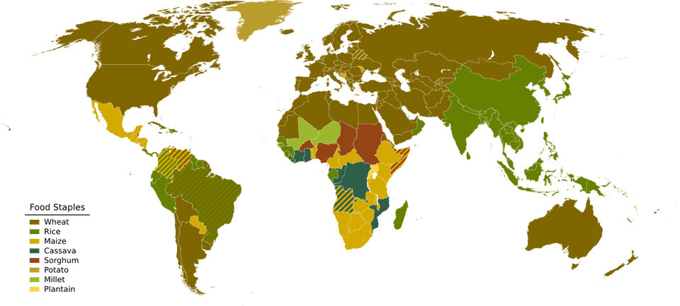

## Grass Family (Poaceae) Most Important to Humans

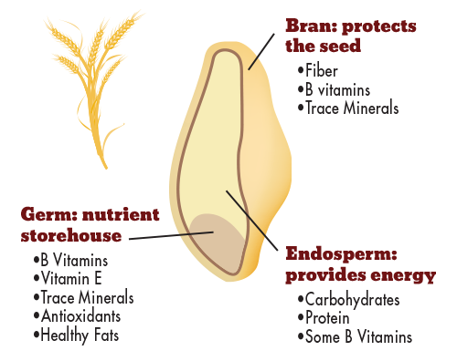

- **Edible grains of cultivated grasses basic food of human civilization**
  - wheat, core, rice
  - barely, oats, millet & rye
- **Sugar cane, a grass, world largest crop product**
  - 26 million hectares in 90 countries
- **Dry fruits from the grass family are ‘grains’**
  - seed is mostly endosperm = starch
  - refined into white flour, corn starch & white rice
  - fruit wall + seed coat = bran fiber
- **Wheat, Maize & Rice (refined + whole) provide 50% of human calories consumed**

## Wheat: The Staff of Life

- **Wheat ‘spikes’ are densely packed with grains**
  - primarily grown in cool temperature zones
  - wild species found in Fertile Crescent
- **Einkorn wheat one of first cultivated species**
  - domesticated form is ‘non-shattering’
  - hybridized with ‘goat grass’ to create ‘emmer wheat’
  - ‘emmer wheat’ crossed with another ‘goat grass’
  - diploid → tetraploid → hexaploid
- **Currently 1,000s of wheat cultivars**
  - tolerance to climate
  - amount of gluten
  - protein content in endosperm

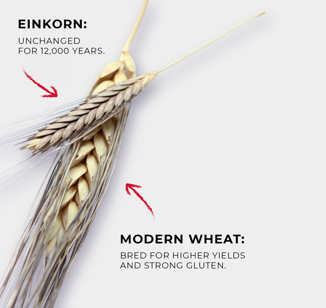

## Corn: Indian Maize

- **Summer annual, moderate temp and rain**
  - now: breed for diverse environments
  - requires nutrient-rich soil
  - today: hybrid corn w/ many large kernels
- **Unknown to arriving Europeans**
  - most types cultivated by Native Americas
  - poorly adapted for natural environment (husks)
- **‘Popcorn’ one of the most primitive varieties**
  - hard kernels, ‘hard’ starch around ‘soft’ starch
  - burst and swell when heated
  - avoids processing

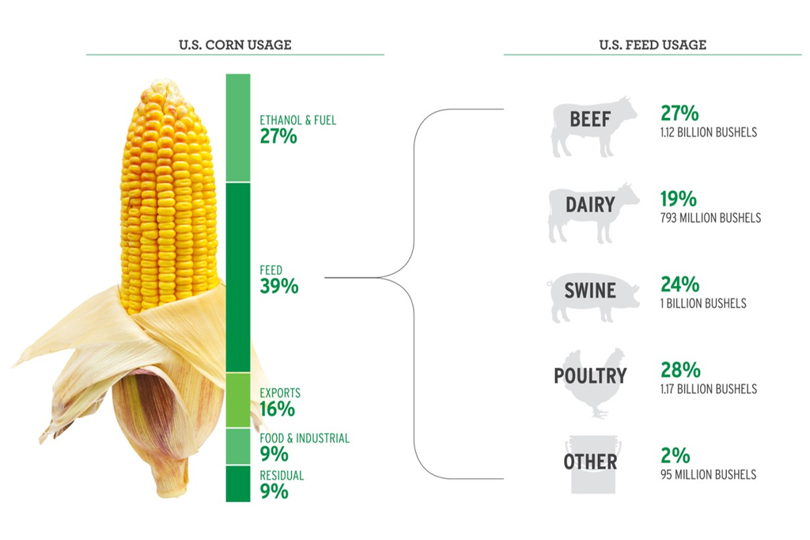

## Rice: Food for Billions

- **Rice feeds more than any other crop**
  - > 2 billion people
  - 1,000’s of varieties
- **Originated from wild ancestor in flooded tropical lowlands**
  - current: breed to grow anywhere
- **Large annual grass with air chambers in stems**
  - air diffusion: stomata → roots
- **Rice mostly cultivated into flooded fields**
  - aquatic fern, *Azolla*, provides nitrogen
  - fields drained to harvest

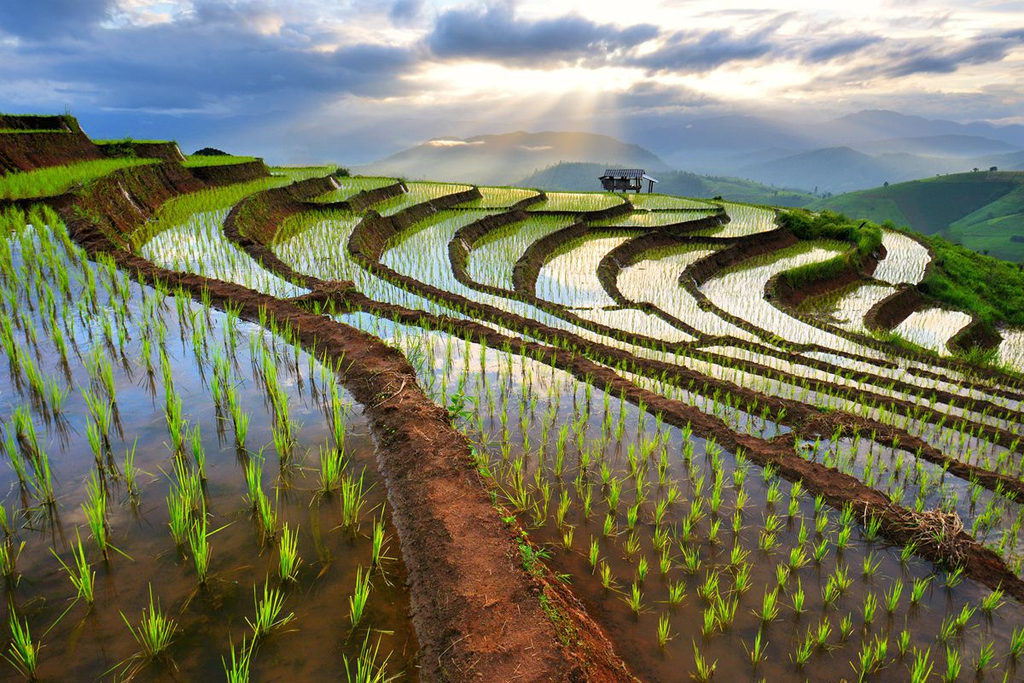

## Rice as Engineered Ecology

- **Rice feeds ~2 billion people globally. Thousands of varieties bred from flood-tolerant ancestors**
- **Rice plants have air spaces in stems (aerenchyma) → O₂ from leaves can diffuse down to submerged roots**
- **Flooded paddies: Suppress many weeds + support Azolla, a tiny floating fern that hosts N-fixing cyanobacteria = natural fertilizer**
  - act like little engineered wetlands

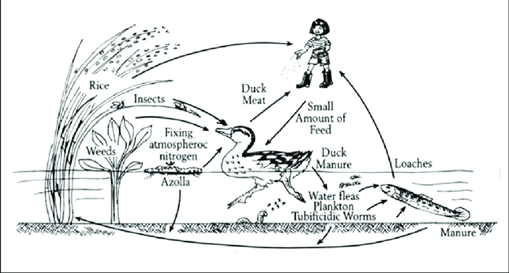

## Food Security vs Monoculture Risk

- **Staple crops are normally grown in huge monocultures**
  - cultivation of a single crop in a given area
  - we are very dependent on a tiny group of grasses to not starve
- **Growing in single-crop fields over huge areas, is efficient — until its not**
  - Disease / pests
  - Climate extremes
  - Political instability in trade
- **One new pathogen, one mega-drought, one supply-chain shock, and millions of people are at risk**
- **Crop genetic diversity = global insurance**
  - Wheat has many cultivars bred for different protein content and climate tolerances

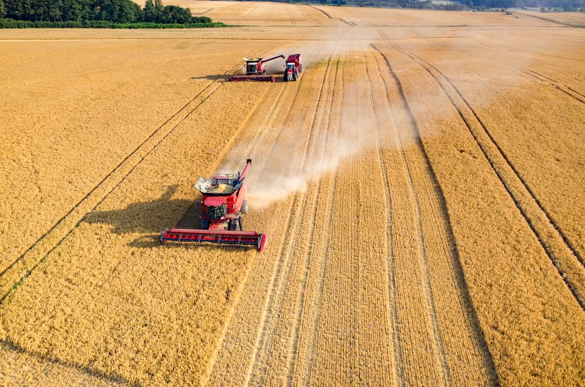